# Analyzing Individual BGG Users

Phil Henrickson

2022-01-02

# **Claywhis’s** BoardGameGeek Collection

This notebook contains a set of analyses for the selected user’s boardgamegeek collection. The bulk of the analysis is focused on building a user-specific predictive model to predict the games that Claywhis is likely to own. This enables to ask questions like, based on the games the user currently owns, what games are a good fit for their collection? What upcoming games are they likely to purchase?

This analysis is based on data from BoardGameGeek that was last updated on **2021-12-20.**

# 1 Collection Overview

We can look at a basic description of the number of games that the user owns, has rated, has previously owned, etc.

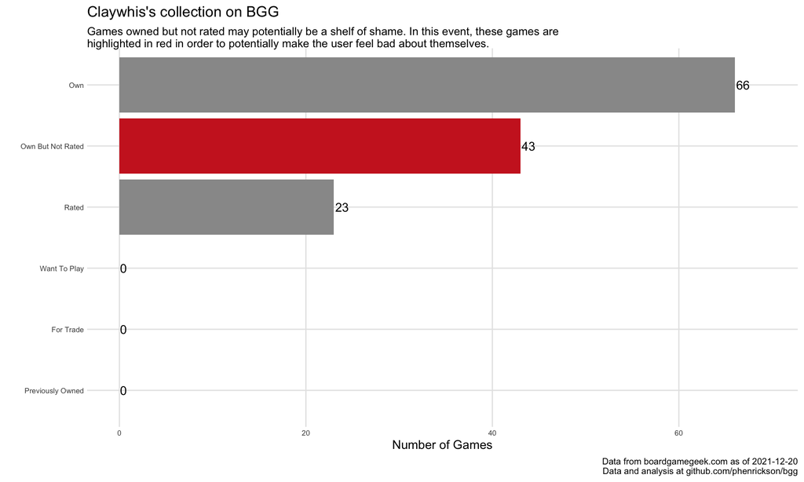

What years has the user owned/rated games from? While we can’t see when a user added or removed a game from their collection, we can look at their collection by the years in which their games were published.

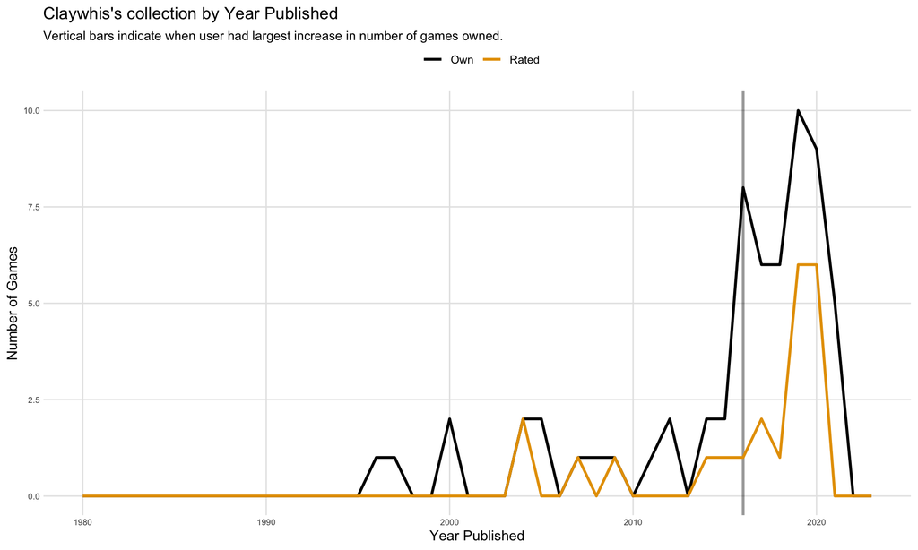

## 1.1 What types of games does Claywhis own?

We can look at the most frequent types of categories, mechanics, designers, and artists that appear in a user’s collection.

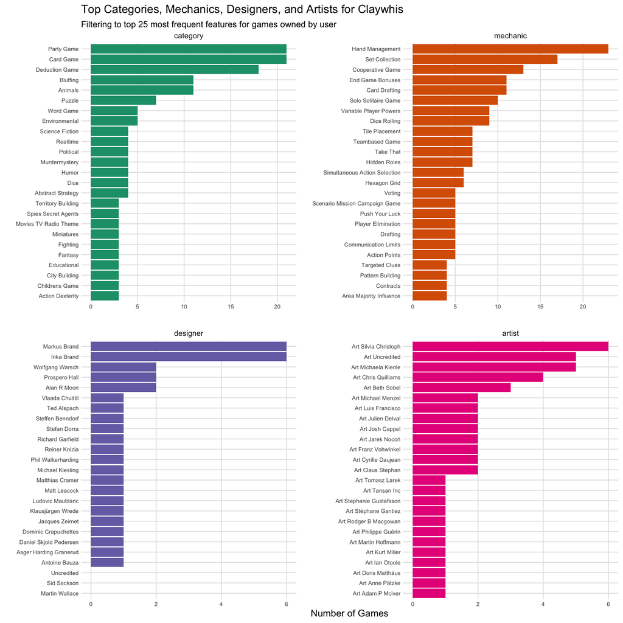

# 2 Modeling **Claywhis’s** Collection

| username | dataset | period | games_owned | games_rated | games_played |
| --- | --- | --- | --- | --- | --- |
| Claywhis | training | published before 2020 | 52 | 17 | 52 |
| Claywhis | test | published 2020 or later | 14 | 6 | 14 |

There are two main (binary) outcomes we will be modeling for the user.

The first, **own** refers to whether the user currently lists a game as owned in their collection. The second, **played** refers to whether the user currently owns, has rated, or previously owned a game. This means the latter will generally have a larger list of games, but may still be a useful category to examine for people who play lots of games without necessarily owning them.

We will train predictive models to learn the probability that the user will own or play individual games based on their features.

## 2.1 Coefficients for Claywhis

We can examine coefficients from the trained modes, which are penalized logistic regressions fit to our two main outcomes. Positive values indicate that a feature increases a user’s probabilility of owning/rating a game, while negative values indicate a feature decreases the probability.

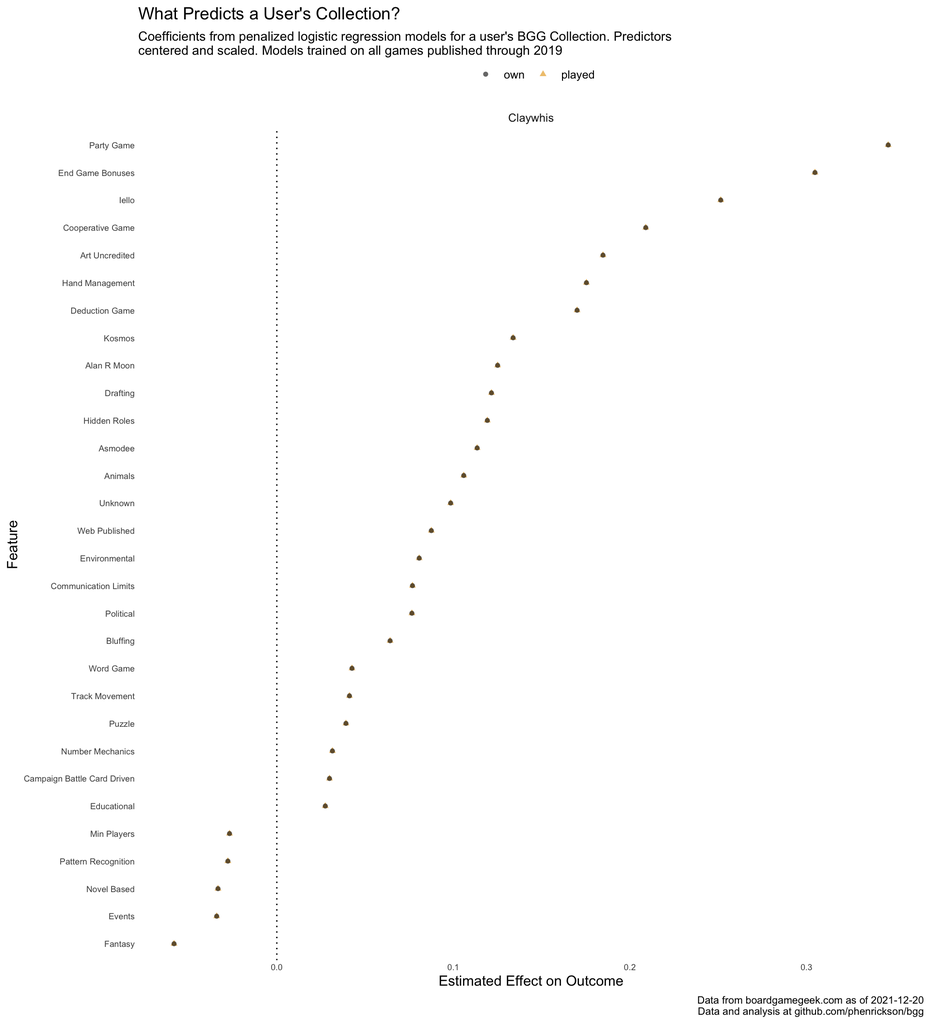

## 2.2 Visualizing Predictors for Claywhis’s Collection

Why did the model identify these features? We can make density plots of the important features for predicting whether the user owned a game. Blue indicates the density for games owned by the user, while grey indicates the density for games not owned by the user.

[figure not shown]

Binary predictors can be difficult to see with this visualization, so we can also directly examine the percentage of games in a user’s collection with a predictor vs the percentage of all games with that predictor.

| username | Feature | % of Games with Feature In_Collection | % of Games with Feature All_Games | Ratio |
| --- | --- | --- | --- | --- |
| Claywhis | End Game Bonuses | 19.2% | 1.2% | 16.3 |
| Claywhis | Hidden Roles | 9.6% | 0.7% | 14.2 |
| Claywhis | Communication Limits | 9.6% | 0.9% | 10.1 |
| Claywhis | Drafting | 9.6% | 1.0% | 9.6 |
| Claywhis | Iello | 21.2% | 3.0% | 7.0 |
| Claywhis | Track Movement | 3.8% | 0.7% | 5.9 |
| Claywhis | Word Game | 9.6% | 1.7% | 5.6 |
| Claywhis | Unknown | 7.7% | 1.5% | 5.3 |
| Claywhis | Environmental | 5.8% | 1.1% | 5.3 |
| Claywhis | Deduction Game | 28.8% | 6.3% | 4.6 |
| Claywhis | Party Game | 34.6% | 8.3% | 4.2 |
| Claywhis | Kosmos | 13.5% | 3.3% | 4.1 |
| Claywhis | Asmodee | 19.2% | 5.3% | 3.6 |
| Claywhis | Web Published | 5.8% | 1.6% | 3.6 |
| Claywhis | Bluffing | 21.2% | 6.7% | 3.2 |
| Claywhis | Puzzle | 9.6% | 3.3% | 2.9 |
| Claywhis | Cooperative Game | 23.1% | 8.5% | 2.7 |
| Claywhis | Political | 7.7% | 3.2% | 2.4 |
| Claywhis | Animals | 15.4% | 6.8% | 2.2 |
| Claywhis | Campaign Battle Card Driven | 5.8% | 3.1% | 1.8 |
| Claywhis | Hand Management | 42.3% | 26.7% | 1.6 |
| Claywhis | Fantasy | 3.8% | 14.9% | 0.3 |
| Claywhis | Events | 0.0% | 2.0% | 0.0 |
| Claywhis | Novel Based | 0.0% | 2.8% | 0.0 |
| Claywhis | Pattern Recognition | 0.0% | 2.5% | 0.0 |

# 3 Assess Model’s Performance on Training Set

Before predicting games in upcoming years, we can examine how well the model did and what games it liked in the training set. In this case, we used resampling techniques (cross validation) to ensure that the model had not seen a game before making its predictions.

## 3.1 Separation Plot

An easy way to examine the performance of classification model is to view a separation plot. We plot the predicted probabilities from the model for every game (from resampling) from lowest to highest. We then overlay a blue line for any game that the user does own. A good classifier is one that is able to *separate* the blue (games owned by the user) from the white (games not owned by the user), with most of the blue occurring at the highest probabilities (right side of the chart).

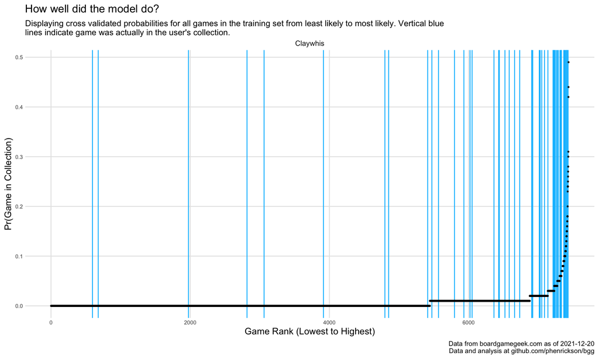

## 3.2 Top Games for **Claywhis** from Training Set

We can display this information in table form, displaying the 100 games with the highest probability of ownership, adding a blue line when the user does own the game.

| username | yearpublished | game_id | name | pred_played | pred_own | actual_played | actual_own |
| --- | --- | --- | --- | --- | --- | --- | --- |
| Claywhis | 2019 | 283863 | The Magnificent | 0.49 | 0.49 | 0 | 0 |
| Claywhis | 2014 | 156129 | Deception: Murder in Hong Kong | 0.44 | 0.44 | 0 | 0 |
| Claywhis | 2014 | 161970 | Alchemists | 0.42 | 0.42 | 0 | 0 |
| Claywhis | 2019 | 260710 | Amul | 0.31 | 0.31 | 0 | 0 |
| Claywhis | 2010 | 62219 | Dominant Species | 0.30 | 0.30 | 0 | 0 |
| Claywhis | 2018 | 205896 | Rising Sun | 0.28 | 0.28 | 0 | 0 |
| Claywhis | 2017 | 184921 | Bunny Kingdom | 0.27 | 0.27 | 0 | 0 |
| Claywhis | 2018 | 225694 | Decrypto | 0.26 | 0.26 | 1 | 1 |
| Claywhis | 2016 | 192291 | Sushi Go Party! | 0.25 | 0.25 | 1 | 1 |
| Claywhis | 2012 | 118048 | Targi | 0.24 | 0.24 | 0 | 0 |
| Claywhis | 2017 | 220775 | Codenames: Disney – Family Edition | 0.24 | 0.24 | 0 | 0 |
| Claywhis | 1900 | 45 | Perudo | 0.24 | 0.24 | 0 | 0 |
| Claywhis | 2016 | 198773 | Codenames: Pictures | 0.23 | 0.23 | 0 | 0 |
| Claywhis | 2013 | 133473 | Sushi Go! | 0.20 | 0.20 | 0 | 0 |
| Claywhis | 2017 | 224037 | Codenames: Duet | 0.18 | 0.18 | 0 | 0 |
| Claywhis | 2011 | 91312 | Discworld: Ankh-Morpork | 0.18 | 0.18 | 0 | 0 |
| Claywhis | 2016 | 191862 | Imhotep | 0.18 | 0.18 | 0 | 0 |
| Claywhis | 2019 | 275467 | Letter Jam | 0.18 | 0.18 | 0 | 0 |
| Claywhis | 2016 | 206051 | Insider | 0.17 | 0.17 | 0 | 0 |
| Claywhis | 2015 | 181304 | Mysterium | 0.17 | 0.17 | 0 | 0 |
| Claywhis | 2019 | 276498 | Paris: La Cité de la Lumière | 0.16 | 0.16 | 0 | 0 |
| Claywhis | 1959 | 7688 | Memory | 0.16 | 0.16 | 0 | 0 |
| Claywhis | 2019 | 271324 | It's a Wonderful World | 0.16 | 0.16 | 0 | 0 |
| Claywhis | 2012 | 126163 | Tzolk'in: The Mayan Calendar | 0.15 | 0.15 | 0 | 0 |
| Claywhis | 2018 | 244711 | Newton | 0.15 | 0.15 | 0 | 0 |
| Claywhis | 2015 | 178900 | Codenames | 0.15 | 0.15 | 1 | 1 |
| Claywhis | 2012 | 131357 | Coup | 0.15 | 0.15 | 1 | 1 |
| Claywhis | 2011 | 70919 | Takenoko | 0.14 | 0.14 | 0 | 0 |
| Claywhis | 2000 | 478 | Citadels | 0.14 | 0.14 | 0 | 0 |
| Claywhis | 2004 | 9220 | Saboteur | 0.14 | 0.14 | 0 | 0 |

[output cut: 70 more lines]

We can also more formally assess how well the model did in resampling by looking at the area under the receiver operating characteristic. A perfect model would receive a score of 1, while a model that cannot predict the outcome will default to a score of 0.5. The extent to which something is a *good* score depends on the setting, but generally anything in the .8 to .9 range is very good while the .7 to .8 range is perfectly acceptable.

| username | outcome_type | .metric | .estimator | .estimate |
| --- | --- | --- | --- | --- |
| Claywhis | own | roc_auc | binary | 0.836 |
| Claywhis | played | roc_auc | binary | 0.836 |

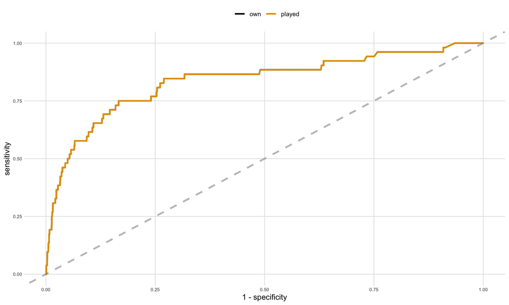

Another way to think about the model performance is to view its lift, or its ability to detect the positive outcomes over that of a null model. High lift indicates the model can much more quickly find all of the positive outcomes (in this case, games owned or played by the user), while a model with no lift is no better than random guessing.

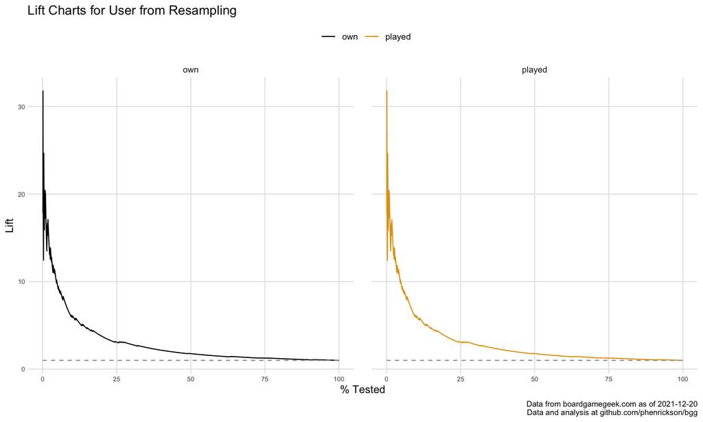

## 3.3 Most and Least Likely Games

What games does the model think Claywhis is **most likely to own** that are **not** in their collection?

| username | yearpublished | game_id | name | pred_own | actual_own |
| --- | --- | --- | --- | --- | --- |
| Claywhis | 2019 | 283863 | The Magnificent | 0.49 | 0 |
| Claywhis | 2014 | 156129 | Deception: Murder in Hong Kong | 0.44 | 0 |
| Claywhis | 2014 | 161970 | Alchemists | 0.42 | 0 |
| Claywhis | 2019 | 260710 | Amul | 0.31 | 0 |
| Claywhis | 2010 | 62219 | Dominant Species | 0.30 | 0 |

What games does the model think Claywhis is **least likely to own** that **are** in their collection?

| username | yearpublished | game_id | name | pred_own | actual_own |
| --- | --- | --- | --- | --- | --- |
| Claywhis | 2007 | 27708 | 1960: The Making of the President | 0 | 1 |
| Claywhis | 2000 | 2655 | Hive | 0 | 1 |
| Claywhis | 2016 | 178336 | World's Fair 1893 | 0 | 1 |
| Claywhis | 2019 | 270314 | Ohanami | 0 | 1 |
| Claywhis | 2018 | 260605 | Camel Up (Second Edition) | 0 | 1 |

## 3.4 Top Games by Year

Top 25 games most likely to be owned by the user in each year, highlighting in blue the games that the user has owned/played.

| rank | 2011 | 2012 | 2013 | 2014 | 2015 | 2016 | 2017 | 2018 | 2019 |
| --- | --- | --- | --- | --- | --- | --- | --- | --- | --- |
| 1 | Discworld: Ankh-Morpork | Targi | Sushi Go! | Deception: Murder in Hong Kong | Mysterium | Sushi Go Party! | Bunny Kingdom | Rising Sun | The Magnificent |
| 2 | Takenoko | Tzolk'in: The Mayan Calendar | Legacy: The Testament of Duke de Crecy | Alchemists | Codenames | Codenames: Pictures | Codenames: Disney – Family Edition | Decrypto | Amul |
| 3 | Rumble in the House | Coup | BANG! The Dice Game | Good Cop Bad Cop | The Pursuit of Happiness | Imhotep | Codenames: Duet | Newton | Letter Jam |
| 4 | Dungeon Fighter | Rumble in the Dungeon | Mascarade | Ultimate Werewolf | One Night Ultimate Werewolf: Daybreak | Insider | Paper Tales | Hail Hydra | Paris: La Cité de la Lumière |
| 5 | Pictomania | One Night Werewolf | Bomb Squad | Camel Up | Tiny Epic Galaxies | Codenames: Deep Undercover | Exit: The Game – The Forbidden Castle | Exit: The Game – The Sinister Mansion | It's a Wonderful World |
| 6 | Tem-Purr-A | A Fake Artist Goes to New York | Concept | Sheriff of Nottingham | Far Space Foundry | Timebomb | Exit: The Game – The Forgotten Island | Shadows: Amsterdam | Wingspan |
| 7 | Ninjato | Legends of Andor | Circus Train (Second Edition) | La Granja | Brick Party | Secret Hitler | Exit: The Game – Dead Man on the Orient Express | Human Punishment: Social Deduction 2.0 | Minecraft: Builders & Biomes |
| 8 | Tales & Games: The Hare & the Tortoise | Kairo | Mini Mölkky | Stay Away! | Grand Austria Hotel | When I Dream | One Night Ultimate Alien | Exit: The Game – The Mysterious Museum | Fiesta de los Muertos |
| 9 | Streams | Santa Cruz | Tajemnicze Domostwo | Templar Intrigue | One Night Ultimate Vampire | Terraforming Mars | Exit: The Game – The Sunken Treasure | Underwater Cities | Exit: The Game – The Stormy Flight |
| 10 | Tragedy Looper | Mini Curling Game | Two Rooms and a Boom | Castles of Mad King Ludwig | The Bloody Inn | Happy Salmon | Exit: The Game – The House of Riddles | Exit: The Game – The Catacombs of Horror | DANY |
| 11 | Tetris Link | Tokaido | Anomia: Party Edition | Five Tribes | One Night Revolution | Hit Z Road | Photosynthesis | Planet | Exit: The Game – Theft on the Mississippi |
| 12 | Telestrations: 12 Player Party Pack | Terra Mystica | Agent Hunter | Witness | Haspelknecht | Evolution: Climate | Werewords | Pax Emancipation | Ecosystem |
| 13 | Rory's Story Cubes: Voyages | Suburbia | Hanamikoji | Spyfall | Unusual Suspects | Dynasties: Heirate & Herrsche | Exit: The Game – The Polar Station | Western Legends | De Vulgari Eloquentia: Deluxe Edition |
| 14 | Skull | Pick-a-Dog | The Witches: A Discworld Game | One Night Ultimate Werewolf | Tales & Games: Little Red Riding Hood | Exit: The Game – The Pharaoh's Tomb | Dracula's Feast | Muse: Awakenings | Maracaibo |
| 15 | Black Stories: Funny Death Edition | Il Vecchio | Theseus: The Dark Orbit | Legendary Encounters: An Alien Deck Building Game | Die Legenden von Andor: Chada & Thorn | Exit: The Game – The Secret Lab | The Chameleon | One Week Ultimate Werewolf | Cities: Skylines – The Board Game |
| 16 | Nightfall | Wits & Wagers Party | Prosperity | Smash Up: Science Fiction Double Feature | Imagine | Exit: The Game – The Abandoned Cabin | Mountains of Madness | Werewords Deluxe Edition | Sierra West |
| 17 | Rhino Hero | Dino Hunt Dice | UGO! | Patchwork | Salem 1692 | Covalence: A Molecule Building Game | Pulsar 2849 | Detective: A Modern Crime Board Game | Old West Empresario |
| 18 | A Few Acres of Snow | Keyflower | Patchistory | Imperial Settlers | FUSE | Escape Room in a Box: The Werewolf Experiment | Azul | Detective Stories: Case 1 – The Fire in Adlerstein | Azul: Summer Pavilion |
| 19 | Steam Torpedo: First Contact | The Resistance: Avalon | Thermopyles | Sheep & Thief | Blood Rage | Loot N Run | Codenames: Marvel | Coimbra | Game of Thrones: Oathbreaker |
| 20 | Carnac | Waka Waka | Wooolf!! | Pictopia: Disney Edition | Qwirkle Cards | Yokohama | Fast Food Fear! | Sherlock: The Tomb of the Archaeologist | One Key |
| 21 | Battleship: Hidden Threat | Smash Up | Nosferatu | 27th Passenger: A Hunt on Rails | Pretense | Escape the Room: Secret of Dr. Gravely's Retreat | Legends of Andor: The Last Hope | Sherlock: Death on the 4th of July | The Crew: The Quest for Planet Nine |
| 22 | Martian Dice | Among the Stars | Hannin Wa Odoru | Piña Pirata | Ion: A Compound Building Game | Junk Art | Pandemic Legacy: Season 2 | Sherlock: Last Call | Chocolate Factory |
| 23 | Dungeon Petz | Freedom: The Underground Railroad | Blood Bound | Coup: Rebellion G54 | The Big Book of Madness | The Manhattan Project: Energy Empire | Rescue Polar Bears: Data & Temperature | Sherlock: 13 Hostages | Barrage |
| 24 | Gears of War: The Board Game | Love Letter | Funemployed | HINT | ...and then, we held hands. | 13 Days: The Cuban Missile Crisis | Gaia Project | DC Spyfall | Pipeline |
| 25 | Santiago de Cuba | Zombicide | Brew Crafters | Spurs: A Tale in the Old West | Smash Up: Pretty Pretty Smash Up | Clank!: A Deck-Building Adventure | Sagrada | Kero | Obscurio |

## 3.5 Interactive Predictions from Resampling

Interactive table for predictions from resampling.

|  | username | yearpublished | rank | game_id | name | pred_played | pred_own | actual_played | actual_own |
| --- | --- | --- | --- | --- | --- | --- | --- | --- | --- |
| 1 | Claywhis | 1900 | 12 | 45 | Perudo | 0.24 | 0.24 | 0 | 0 |
| 2 | Claywhis | 1900 | 83 | 2785 | Game of Goose | 0.08 | 0.08 | 0 | 0 |
| 3 | Claywhis | 1900 | 93 | 21389 | Happy Families | 0.07 | 0.07 | 0 | 0 |
| 4 | Claywhis | 1900 | 98 | 5122 | Charades | 0.07 | 0.07 | 0 | 0 |
| 5 | Claywhis | 1900 | 207 | 188 | Go | 0.03 | 0.03 | 0 | 0 |
| 6 | Claywhis | 1900 | 275 | 11670 | The Game of Authors | 0.03 | 0.03 | 0 | 0 |
| 7 | Claywhis | 1900 | 278 | 2394 | Dominoes | 0.03 | 0.03 | 0 | 0 |
| 8 | Claywhis | 1900 | 311 | 2389 | Othello | 0.02 | 0.02 | 0 | 0 |
| 9 | Claywhis | 1900 | 368 | 9851 | Shut the Box | 0.02 | 0.02 | 0 | 0 |
| 10 | Claywhis | 1900 | 460 | 15878 | Rummy | 0.02 | 0.02 | 0 | 0 |

[output cut: 7426 more lines]

# 4 Validating the Model on 2020

How well did a model trained on a user’s collection through 2019 perform in predicting games for the user from 2020?

| username | outcome_type | yearpublished | .metric | .estimator | .estimate |
| --- | --- | --- | --- | --- | --- |
| Claywhis | own | 2020 | roc_auc | binary | 0.709 |
| Claywhis | played | 2020 | roc_auc | binary | 0.709 |

Table of top 25 games from 2020, highlighting games that the user owns.

| username | yearpublished | game_id | name | pred_own | pred_played | actual_own | actual_played |
| --- | --- | --- | --- | --- | --- | --- | --- |
| Claywhis | 2020 | 311193 | Anno 1800 | 0.22 | 0.22 | 0 | 0 |
| Claywhis | 2020 | 184267 | On Mars | 0.19 | 0.19 | 0 | 0 |
| Claywhis | 2020 | 323784 | Ghost Letters | 0.15 | 0.15 | 0 | 0 |
| Claywhis | 2020 | 299960 | Alma Mater | 0.13 | 0.13 | 0 | 0 |
| Claywhis | 2020 | 261403 | Inhuman Conditions | 0.12 | 0.12 | 0 | 0 |
| Claywhis | 2020 | 307844 | Atheneum: Mystic Library | 0.12 | 0.12 | 0 | 0 |
| Claywhis | 2020 | 297204 | Traintopia | 0.10 | 0.10 | 0 | 0 |
| Claywhis | 2020 | 256317 | Guild Master | 0.09 | 0.09 | 0 | 0 |
| Claywhis | 2020 | 300322 | Hallertau | 0.09 | 0.09 | 0 | 0 |
| Claywhis | 2020 | 301767 | Mysterium Park | 0.09 | 0.09 | 0 | 0 |
| Claywhis | 2020 | 277927 | Bites | 0.08 | 0.08 | 0 | 0 |
| Claywhis | 2020 | 302734 | Master Word | 0.08 | 0.08 | 0 | 0 |
| Claywhis | 2020 | 227224 | The Red Cathedral | 0.07 | 0.07 | 0 | 0 |
| Claywhis | 2020 | 253506 | Versailles 1919 | 0.07 | 0.07 | 0 | 0 |
| Claywhis | 2020 | 298371 | Wild Space | 0.07 | 0.07 | 0 | 0 |
| Claywhis | 2020 | 307997 | Insider Black | 0.07 | 0.07 | 0 | 0 |
| Claywhis | 2020 | 308765 | Praga Caput Regni | 0.07 | 0.07 | 0 | 0 |
| Claywhis | 2020 | 312762 | The Joker | 0.07 | 0.07 | 0 | 0 |
| Claywhis | 2020 | 313817 | Hello Neighbor: The Secret Neighbor Party Game | 0.07 | 0.07 | 0 | 0 |
| Claywhis | 2020 | 245658 | Unicorn Fever | 0.06 | 0.06 | 0 | 0 |
| Claywhis | 2020 | 279537 | The Search for Planet X | 0.06 | 0.06 | 1 | 1 |
| Claywhis | 2020 | 320819 | Dinner in Paris | 0.06 | 0.06 | 0 | 0 |
| Claywhis | 2020 | 296151 | Viscounts of the West Kingdom | 0.05 | 0.05 | 0 | 0 |
| Claywhis | 2020 | 310968 | Bite and Write: The Treaty of Rodentia | 0.05 | 0.05 | 0 | 0 |
| Claywhis | 2020 | 315954 | Hunt A Killer: Death at the Dive Bar | 0.05 | 0.05 | 1 | 1 |

# 5 Predicting Upcoming Games (2020 and On) for **Claywhis**

Examine the top games for the test set.

| username | yearpublished | game_id | name | rank | own | played |
| --- | --- | --- | --- | --- | --- | --- |
| Claywhis | 2020 | 311193 | Anno 1800 | 1 | 0.22 | 0.22 |
| Claywhis | 2020 | 184267 | On Mars | 2 | 0.19 | 0.19 |
| Claywhis | 2020 | 323784 | Ghost Letters | 3 | 0.15 | 0.15 |
| Claywhis | 2020 | 299960 | Alma Mater | 4 | 0.13 | 0.13 |
| Claywhis | 2020 | 261403 | Inhuman Conditions | 5 | 0.12 | 0.12 |
| Claywhis | 2020 | 307844 | Atheneum: Mystic Library | 6 | 0.12 | 0.12 |
| Claywhis | 2020 | 297204 | Traintopia | 7 | 0.10 | 0.10 |
| Claywhis | 2020 | 301767 | Mysterium Park | 8 | 0.09 | 0.09 |
| Claywhis | 2020 | 256317 | Guild Master | 9 | 0.09 | 0.09 |
| Claywhis | 2020 | 300322 | Hallertau | 10 | 0.09 | 0.09 |
| Claywhis | 2020 | 277927 | Bites | 11 | 0.08 | 0.08 |
| Claywhis | 2020 | 302734 | Master Word | 12 | 0.08 | 0.08 |
| Claywhis | 2020 | 253506 | Versailles 1919 | 13 | 0.07 | 0.07 |
| Claywhis | 2020 | 313817 | Hello Neighbor: The Secret Neighbor Party Game | 14 | 0.07 | 0.07 |
| Claywhis | 2020 | 308765 | Praga Caput Regni | 15 | 0.07 | 0.07 |
| Claywhis | 2020 | 307997 | Insider Black | 16 | 0.07 | 0.07 |
| Claywhis | 2020 | 227224 | The Red Cathedral | 17 | 0.07 | 0.07 |
| Claywhis | 2020 | 298371 | Wild Space | 18 | 0.07 | 0.07 |
| Claywhis | 2020 | 312762 | The Joker | 19 | 0.07 | 0.07 |
| Claywhis | 2020 | 320819 | Dinner in Paris | 20 | 0.06 | 0.06 |
| Claywhis | 2020 | 245658 | Unicorn Fever | 21 | 0.06 | 0.06 |
| Claywhis | 2020 | 279537 | The Search for Planet X | 22 | 0.06 | 0.06 |
| Claywhis | 2020 | 315954 | Hunt A Killer: Death at the Dive Bar | 23 | 0.05 | 0.05 |
| Claywhis | 2020 | 310968 | Bite and Write: The Treaty of Rodentia | 24 | 0.05 | 0.05 |
| Claywhis | 2020 | 296151 | Viscounts of the West Kingdom | 25 | 0.05 | 0.05 |
| Claywhis | 2021 | 291847 | Mantis Falls | 1 | 0.16 | 0.16 |
| Claywhis | 2021 | 342942 | Ark Nova | 2 | 0.15 | 0.15 |
| Claywhis | 2021 | 298102 | Roll Camera!: The Filmmaking Board Game | 3 | 0.14 | 0.14 |
| Claywhis | 2021 | 337262 | Fangs | 4 | 0.13 | 0.13 |
| Claywhis | 2021 | 315624 | World Changers | 5 | 0.12 | 0.12 |
| Claywhis | 2021 | 319999 | Dungeon Decorators | 6 | 0.10 | 0.10 |
| Claywhis | 2021 | 337117 | RATS: High Tea at Sea | 7 | 0.09 | 0.09 |
| Claywhis | 2021 | 337389 | Snakesss | 8 | 0.09 | 0.09 |
| Claywhis | 2021 | 324856 | The Crew: Mission Deep Sea | 9 | 0.08 | 0.08 |
| Claywhis | 2021 | 309408 | Arcana Rising | 10 | 0.08 | 0.08 |
| Claywhis | 2021 | 309207 | City Builder: Ancient World | 11 | 0.07 | 0.07 |
| Claywhis | 2021 | 306321 | Night of the Ninja | 12 | 0.07 | 0.07 |
| Claywhis | 2021 | 343905 | Boonlake | 13 | 0.07 | 0.07 |
| Claywhis | 2021 | 308989 | Bristol 1350 | 14 | 0.06 | 0.06 |
| Claywhis | 2021 | 316287 | Quest | 15 | 0.06 | 0.06 |
| Claywhis | 2021 | 337269 | Terra Futura | 16 | 0.06 | 0.06 |
| Claywhis | 2021 | 336552 | Mystic Paths | 17 | 0.05 | 0.05 |
| Claywhis | 2021 | 332944 | Sobek: 2 Players | 18 | 0.05 | 0.05 |
| Claywhis | 2021 | 295147 | Good Puppers | 19 | 0.05 | 0.05 |
| Claywhis | 2021 | 295681 | In Too Deep | 20 | 0.05 | 0.05 |
| Claywhis | 2021 | 318182 | Imperium: Legends | 21 | 0.05 | 0.05 |
| Claywhis | 2021 | 330806 | Silverwood Grove | 22 | 0.05 | 0.05 |
| Claywhis | 2021 | 318184 | Imperium: Classics | 23 | 0.05 | 0.05 |
| Claywhis | 2021 | 282776 | Tumble Town | 24 | 0.05 | 0.05 |
| Claywhis | 2021 | 300217 | Merchants of the Dark Road | 25 | 0.04 | 0.04 |
| Claywhis | 2022 | 320718 | Hidden Leaders | 1 | 0.14 | 0.14 |
| Claywhis | 2022 | 317511 | Tindaya | 2 | 0.12 | 0.12 |
| Claywhis | 2022 | 240980 | Blood on the Clocktower | 3 | 0.07 | 0.07 |
| Claywhis | 2022 | 336986 | Flamecraft | 4 | 0.07 | 0.07 |
| Claywhis | 2022 | 345868 | Federation | 5 | 0.05 | 0.05 |
| Claywhis | 2022 | 324090 | Scarface 1920 | 6 | 0.05 | 0.05 |
| Claywhis | 2022 | 304051 | Creature Comforts | 7 | 0.05 | 0.05 |
| Claywhis | 2022 | 335427 | Wild: Serengeti | 8 | 0.05 | 0.05 |
| Claywhis | 2022 | 305096 | Endless Winter: Paleoamericans | 9 | 0.05 | 0.05 |
| Claywhis | 2022 | 280726 | Legacies | 10 | 0.04 | 0.04 |
| Claywhis | 2022 | 326945 | Castles of Mad King Ludwig: Collector's Edition | 11 | 0.04 | 0.04 |
| Claywhis | 2022 | 334065 | Verdant | 12 | 0.03 | 0.03 |
| Claywhis | 2022 | 295374 | Long Shot: The Dice Game | 13 | 0.03 | 0.03 |
| Claywhis | 2022 | 319807 | Shogun no Katana | 14 | 0.03 | 0.03 |
| Claywhis | 2022 | 283137 | Human Punishment: The Beginning | 15 | 0.03 | 0.03 |
| Claywhis | 2022 | 339592 | Sheep in Disguise | 16 | 0.02 | 0.02 |
| Claywhis | 2022 | 295770 | Frosthaven | 17 | 0.02 | 0.02 |
| Claywhis | 2022 | 316624 | Stationfall | 18 | 0.02 | 0.02 |
| Claywhis | 2022 | 271601 | Feed the Kraken | 19 | 0.02 | 0.02 |
| Claywhis | 2022 | 348463 | ECO: Coral Reef | 20 | 0.02 | 0.02 |
| Claywhis | 2022 | 311988 | Frostpunk: The Board Game | 21 | 0.01 | 0.01 |
| Claywhis | 2022 | 281549 | Beast | 22 | 0.01 | 0.01 |
| Claywhis | 2022 | 331401 | Dog Park | 23 | 0.01 | 0.01 |
| Claywhis | 2022 | 293941 | Mage Noir | 24 | 0.01 | 0.01 |
| Claywhis | 2022 | 284118 | Mechanical Beast | 25 | 0.01 | 0.01 |

## 5.1 Interactive Table for Upcoming Games 2020 and On

|  | username | yearpublished | game_id | name | rank | own | played |
| --- | --- | --- | --- | --- | --- | --- | --- |
| 1 | Claywhis | 2020 | 311193 | Anno 1800 | 1 | 0.22 | 0.22 |
| 2 | Claywhis | 2020 | 184267 | On Mars | 2 | 0.19 | 0.19 |
| 3 | Claywhis | 2021 | 291847 | Mantis Falls | 3 | 0.16 | 0.16 |
| 4 | Claywhis | 2020 | 323784 | Ghost Letters | 4 | 0.15 | 0.15 |
| 5 | Claywhis | 2021 | 342942 | Ark Nova | 5 | 0.15 | 0.15 |
| 6 | Claywhis | 2021 | 298102 | Roll Camera!: The Filmmaking Board Game | 6 | 0.14 | 0.14 |
| 7 | Claywhis | 2022 | 320718 | Hidden Leaders | 7 | 0.14 | 0.14 |
| 8 | Claywhis | 2021 | 337262 | Fangs | 8 | 0.13 | 0.13 |
| 9 | Claywhis | 2020 | 299960 | Alma Mater | 9 | 0.13 | 0.13 |
| 10 | Claywhis | 2021 | 315624 | World Changers | 10 | 0.12 | 0.12 |

[output cut: 1627 more lines]